# *Tree vs Forest*

# A Must Read !!

## Visualization of the Decision tree

- http://www.r2d3.us/visual-intro-to-machine-learning-part-1/

## Bias and Variance :

- http://www.r2d3.us/visual-intro-to-machine-learning-part-2/

## Lets See the Practical problems in Decision Tree -

## Before that Lets have a quick question !

## What is difference between Hyperparameters and Paramaters of the model!??

## Lets have a look at Decision Tree's Hyperparameters

```python
from sklearn.tree import DecisionTreeClassifier,DecisionTreeRegressor
from sklearn.ensemble import RandomForestClassifier,RandomForestRegressor
```

## Decision tree Paramaters and Attributes

```python
dtr=DecisionTreeClassifier()
dtr.get_params
```

[output not shown]

```python
DecisionTreeClassifier??
```

```python
dir(dtr)
```

[output not shown]

# Drawbacks of Descision Tree Based Modeling

- Prune to Overfiting !!
- They are **unstable**, meaning that a small change in the data can lead to a large change in the structure of the optimal decision tree.
- They are often relatively inaccurate. Many other predictors perform better with similar data. This can be remedied by replacing a single decision tree with a random forest of decision trees, but a random forest is not as easy to interpret as a single decision tree.
- For data including categorical variables with different number of levels, information gain in decision trees is biased in favor of those attributes with more levels
- Calculations can get very **complex**, particularly if many values are uncertain and/or if many outcomes are linked

# Random Forest

[figure not shown]

- ## What is Random ??
- ## why we call it as Forest ??

# What is a Good Decision ??

```
- Single Individual's decision won't be a good decision all the time (sometimes though)
- Good Decision and Bad Decision are again subjective  (varies from person to person ,situation to situation)
- ## Atlast everything is all about statisfaction
```

# Why Random Forest works well/better in practice !?

# wisdom of the crowds

## Team work was always the answer to the any particular problem

- ### There are many experiment conducted to prove this !!

## Physcological perspective :

- Find the solution for the particular problem based on knowledge /suggestion from many such individuals and decide accordingly
- Choose those individuals wisely

## There was another Experiement Related to the Neuroscience

```
(easy to explain hard to write)
```

# Random Forest

[figure not shown]

# Ensemble (together):

```
Ensemble  is a collection of learners (base estimators ) which in turn builts the Strong Predictor or Learning strategy

You can combine any predictor or learning algorithms (not just trees) to achieve your end goal (high accuarcy )
(but consider Generilization Error)
```

## Types of Ensemble modeling

- Bagging
- Boosting
- Stacking

# Bagging (Random Forest )

[figure not shown]

# Boosting (Gradient Boosting)

[figure not shown]

# Stacking (stacking two or three models)

[figure not shown]

## Success of Ensemble Modeling

Success of your model really lies in **modeling each individual tree as different as possible** (uncorrelated )

## How to achieve the possible differnce between the models ?

- Difference in population
- Difference in hypothesis
- Difference in modeling technique
- Difference in initial seed

Refrence :

- https://www.analyticsvidhya.com/blog/2015/08/introduction-ensemble-learning/

# Hyperparameters for Decision Tree and Random Forest

[figure not shown]

## TIPS and Tricks to Use RandomForest for various things

```python
from sklearn.datasets import load_boston,load_wine
import pandas as pd
from sklearn.model_selection import train_test_split
import matplotlib.pyplot as plt
from sklearn import metrics
import math
import numpy as np
from sklearn.ensemble import RandomForestClassifier,RandomForestRegressor
```

```python
def rmse(x,y): return math.sqrt(((x-y)**2).mean())

def print_score(m):
    res = [rmse(m.predict(X_train), y_train), rmse(m.predict(X_test), y_test),
                m.score(X_train, y_train), m.score(X_test, y_test)]
    if hasattr(m, 'oob_score_'): res.append(m.oob_score_)
    print(res)
```

```python
house_price=load_boston(return_X_y=False)
```

```python
#house_price['data']
#house_price['feature_names']
#house_price['target']
X_df=pd.DataFrame(data=house_price['data'],columns=house_price['feature_names'])
y=house_price['target']
X_df.head(10)
```

|  | CRIM | ZN | INDUS | CHAS | NOX | RM | AGE | DIS | RAD | TAX | PTRATIO | B | LSTAT |
| --- | --- | --- | --- | --- | --- | --- | --- | --- | --- | --- | --- | --- | --- |
| 0 | 0.00632 | 18.0 | 2.31 | 0.0 | 0.538 | 6.575 | 65.2 | 4.0900 | 1.0 | 296.0 | 15.3 | 396.90 | 4.98 |
| 1 | 0.02731 | 0.0 | 7.07 | 0.0 | 0.469 | 6.421 | 78.9 | 4.9671 | 2.0 | 242.0 | 17.8 | 396.90 | 9.14 |
| 2 | 0.02729 | 0.0 | 7.07 | 0.0 | 0.469 | 7.185 | 61.1 | 4.9671 | 2.0 | 242.0 | 17.8 | 392.83 | 4.03 |
| 3 | 0.03237 | 0.0 | 2.18 | 0.0 | 0.458 | 6.998 | 45.8 | 6.0622 | 3.0 | 222.0 | 18.7 | 394.63 | 2.94 |
| 4 | 0.06905 | 0.0 | 2.18 | 0.0 | 0.458 | 7.147 | 54.2 | 6.0622 | 3.0 | 222.0 | 18.7 | 396.90 | 5.33 |
| 5 | 0.02985 | 0.0 | 2.18 | 0.0 | 0.458 | 6.430 | 58.7 | 6.0622 | 3.0 | 222.0 | 18.7 | 394.12 | 5.21 |
| 6 | 0.08829 | 12.5 | 7.87 | 0.0 | 0.524 | 6.012 | 66.6 | 5.5605 | 5.0 | 311.0 | 15.2 | 395.60 | 12.43 |
| 7 | 0.14455 | 12.5 | 7.87 | 0.0 | 0.524 | 6.172 | 96.1 | 5.9505 | 5.0 | 311.0 | 15.2 | 396.90 | 19.15 |
| 8 | 0.21124 | 12.5 | 7.87 | 0.0 | 0.524 | 5.631 | 100.0 | 6.0821 | 5.0 | 311.0 | 15.2 | 386.63 | 29.93 |
| 9 | 0.17004 | 12.5 | 7.87 | 0.0 | 0.524 | 6.004 | 85.9 | 6.5921 | 5.0 | 311.0 | 15.2 | 386.71 | 17.10 |

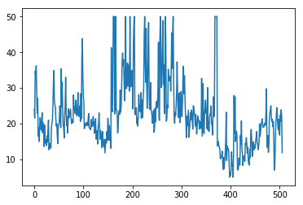

```python
plt.plot(y)
plt.show()
```

```python
preds = np.stack([t.predict(X_test) for t in m.estimators_])
preds[:,0], np.mean(preds[:,0]), y_test[0]
```

```
(array([17.5, 18.4, 17.1, 18.9, 17.1, 17.4, 17.8, 17.1, 19.4, 18.1]),
 17.880000000000003,
 18.0)
```

```python
preds.shape
pred=m.predict(X_test)
interval=+np.std(preds)
```

```python
index=list(range(len(pred)))
```

## Getting Confidence interval

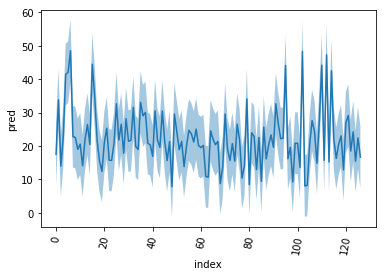

```python
plt.figure()
plt.plot(index,pred)

#plt.plot(dataframe.index,dataframe[col_name],label='original')
#plt.plot(dataframe.index,predicted_gb,label='predicted gradient descent')
#plt.plot(dataframe.index,upper,label='upper_boundary')
#plt.plot(dataframe.index,lower,label='lower_boundary')
lower=pred-np.std(preds)
upper=pred+np.std(preds)
plt.xticks(rotation=80)
plt.xlabel('index')
plt.ylabel('pred')
plt.fill_between(index,lower,upper,alpha=0.4)
plt.show()
```

[figure not shown]

```python
plt.plot(pred+np.std(preds))
plt.show()
```

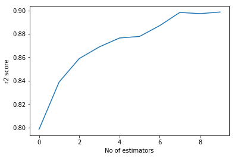

```python
plt.plot([metrics.r2_score(y_test, np.mean(preds[:i+1], axis=0)) for i in range(10)])
plt.xlabel('No of estimators')
plt.ylabel('r2 score')
plt.show()
```

```python
m = RandomForestRegressor(n_estimators=20, n_jobs=-1)
m.fit(X_train, y_train)
print_score(m)
```

```
[1.4930752207359566, 2.974918744341275, 0.973025435502141, 0.9008199569087996]
```

```python
m = RandomForestRegressor(n_estimators=40, n_jobs=-1)
m.fit(X_train, y_train)
print_score(m)
```

```
[1.371449205097873, 2.874513798326886, 0.9772411391697727, 0.9074017302211023]
```

```python
m = RandomForestRegressor(n_estimators=80, n_jobs=-1)
m.fit(X_train, y_train)
print_score(m)
```

```
[1.3701758124748178, 2.93752818925995, 0.9772833828211569, 0.9032973974763153]
```

# Hierarchical Clustering

- http://www.statisticshowto.com/hierarchical-clustering/

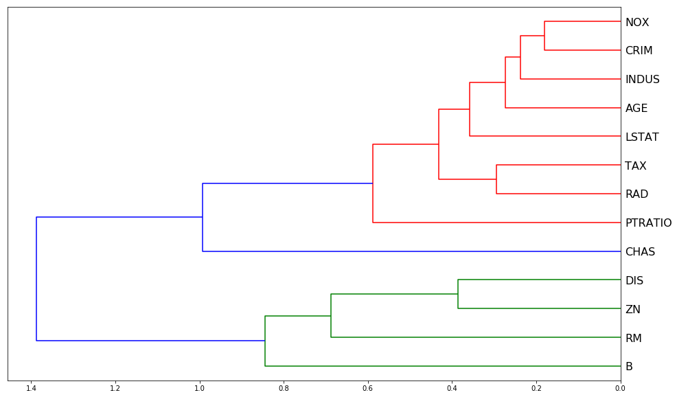

```python
import scipy
from scipy.cluster import hierarchy as hc
corr = np.round(scipy.stats.spearmanr(X_df).correlation, 4)
corr_condensed = hc.distance.squareform(1-corr)
z = hc.linkage(corr_condensed, method='average')
fig = plt.figure(figsize=(16,10))
dendrogram = hc.dendrogram(z, labels=X_df.columns, orientation='left', leaf_font_size=16)
plt.show()
```

```python
!pip install pdpbox
```

```
  Running setup.py bdist_wheel for pdpbox: started
  Running setup.py bdist_wheel for pdpbox: finished with status 'done'
```

# pdpbox

When using black box machine learning algorithms like random forest and boosting, it is hard to understand the relations between predictors and model outcome.

For example, in terms of random forest, all we get is the feature importance. Although we can know which feature is significantly influencing the outcome based on the importance calculation, it really sucks that we don’t know in which direction it is influencing. And in most of the real cases, the effect is non-monotonic.

We need some powerful tools to help understanding the complex relations between predictors and model prediction. Refer :https://github.com/SauceCat/PDPbox/tree/master/tutorials

# Highlight

- Helper functions for visualizing target distribution as well as prediction distribution.
- Proper way to handle one-hot encoding features.
- Solution for handling complex mutual dependency among features.
- Support multi-class classifier.
- Support two variable interaction partial dependence plot.

```python
from pdpbox import pdp
#from plotnine import *
```

```python
pdp.pdp_isolate?
```

```python
X_train.shape,X_df.shape
```

```
((379, 13), (506, 13))
```

```
CRIM
```

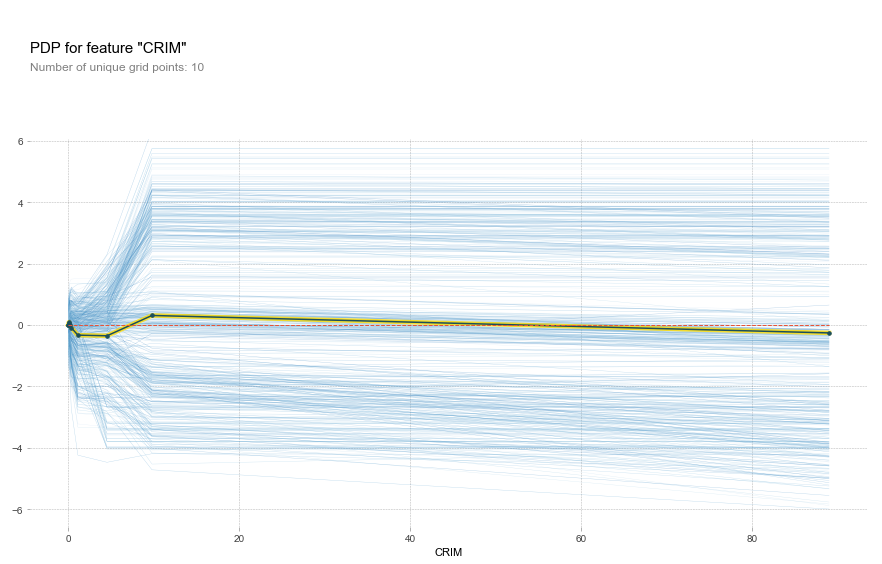

```python
def plot_pdp(feat, clusters=None, feat_name=None):
    feat_name = feat_name or feat
    p = pdp.pdp_isolate(model=m, dataset=X_df, feature=feat,model_features=feats)
    return pdp.pdp_plot(p, feat_name, plot_lines=True,
                        cluster=clusters is not None, n_cluster_centers=clusters)
print(feats[0])
plot_pdp(feats[0])
plt.show()
```

```
13
```

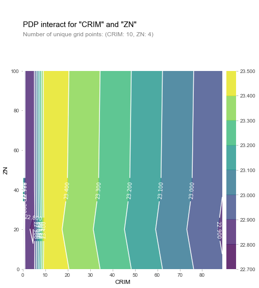

```python
feats = house_price['feature_names']
print(len(feats))
p = pdp.pdp_interact(m, X_df, feats,features=house_price['feature_names'])
pdp.pdp_interact_plot(p, feats)
plt.show()
```

```python
RandomForestClassifier??
```

## Hyperparamaters :

```
* n_estimators
* OOb score
* Min samples_leaf
* max_features
```

## n_estimators :

```
    Sklearn acronym for Decision Tree ,specify the Number of Decision trees to use ,to built the Randomforest
```

## OOB Score :

```
    Out of Bag Score :which is the validation score obtained from different Decision Trees(Estimators)when you are
    building the tree (used for validation no effect during training)
```

## Min samples_leaf

```
    Minimum Number of samples to be accepted as leaf
```

# Max features (try to guess this):

```
I assumed this one as enterily wrong this many days ,Yesterday i got wisdom ,about what  max features really is !?
```

- The number of features to consider when looking for the best split
- http://scikit-learn.org/stable/auto_examples/ensemble/plot_ensemble_oob.html

## All the other paramaters are likely a variant of this parameters ,(sklearn documentation gives good clarity to differentaite between these parameters)

# References

## Physcological perspective :

```
https://www.nationalgeographic.com/science/phenomena/2013/01/31/the-real-wisdom-of-the-crowds/
```

## Model Perspective:

```
http://dataaspirant.com/2017/05/22/random-forest-algorithm-machine-learing/
https://towardsdatascience.com/the-random-forest-algorithm-d457d499ffcd
https://link.springer.com/content/pdf/10.1023%2FA%3A1010933404324.pdf
```